# Day 9 Hypothesis Testing

Md Rana Mahmud

9/18/2020

# Inference concerning the mean

## Normal population-varaince known

Suppose a sample of size n from normal population with mean $\mu$ and known variance $\sigma^2$

$H_{0}: \mu = \mu_{0}$ $H_{1}: \mu \ne \mu_{0}$

if population not normal we can use this test if n is large >30

Shapiro-Wilk normality test

average longevity of bulb is 4 years, standard deviation 0.16, random sample of 40 gave mean 3.45 Two tailed test example mn islam 11.5 alpha = 0.05

```r
# normal test
x_bar <- 3.45
n <- 40
mu_not <- 4
sigma <- 0.16
z_statistics  <- (x_bar - mu_not)/(sigma/sqrt(n))
z_statistics
```

```
## [1] -21.74066
```

```r
# 0.05
# 0.025
# 1- 0.025
qnorm(c(0.025, 0.975))
```

```
## [1] -1.959964  1.959964
```

```r
# critical value -1.96
2*pnorm(-abs(z_statistics))
```

```
## [1] 8.467452e-105
```

Reject null hypothesis

```r
mu_not - 1.96*(sigma/sqrt(n))
```

```
## [1] 3.950415
```

```r
mu_not + 1.96*(sigma/sqrt(n))
```

```
## [1] 4.049585
```

1. compairing test statistics
2. confidence interval
3. p value calculate

## normal population variance unknown-sample size small

$t = \dfrac{\overline{x} - \mu_{0}}{s/\sqrt(n)}$ with n-1 df t distribution instead of normal

example mn inslam book 11.11

tensile strength of steel averge 120 pounds, sample 25, sample mean 110 pounds, sample variance 144

```r
x_bar <- 110
n <- 25
mu_not <- 120
s <- 12
t_statistics  <- (x_bar - mu_not)/(s/sqrt(n))
t_statistics
```

```
## [1] -4.166667
```

```r
# from t distribution
# p value
2*pt(-abs(t_statistics),df=n-1)
```

```
## [1] 0.0003455224
```

```r
# critical region
qt(c(.025, .975), df=n-1)
```

```
## [1] -2.063899  2.063899
```

reject null hypothesis

## difference between two mean

### testing equality of two population means

assumptions populations are normal with known but unequal variance drawn independentlly from the populations

example 11.14

trival women 12, non trival 15, average children respectively 4.5, 3.4,population variance 1 and 1.5 respectively

```r
n1 <- 12
n2 <- 15
x1_bar <- 4.5
x2_bar <- 3.4
sigma_sq_1 <- 1
sigma_sq_2 <- 1.5

z <- (x1_bar-x2_bar)/(sqrt((sigma_sq_1/n1)+sigma_sq_2/n2))
z
```

```
## [1] 2.569047
```

```r
# critical region
qnorm(c(0.025,0.975))
```

```
## [1] -1.959964  1.959964
```

```r
2*pnorm(-abs(z))
```

```
## [1] 0.01019788
```

Population Variance unknown small sample assuming two indepndent population

example 11.18

difference 7.5 due to regional difernce or real difference

```r
n1 <- 16
n2 <- 14
x1_bar <- 70.2
x2_bar <- 62.7
sigma_sq_1 <- 8.4^2
sigma_sq_2 <- 7.5^2

sp_sq <- ((n1-1)*sigma_sq_1 + (n2-1)*sigma_sq_2)/(n1+n2-2)
sp_sq
```

```
## [1] 63.91607
```

```r
t <- (x1_bar -x2_bar)/(sqrt(sp_sq)*sqrt(1/n1+1/n2))
t
```

```
## [1] 2.563419
```

```r
# critical region
qt(c(0.025,0.975), n1+n2-2)
```

```
## [1] -2.048407  2.048407
```

```r
pt(-abs(t),df=n1+n2-2)
```

```
## [1] 0.008012206
```

reject null hypothesis

bating average of two places is due to chance is less than 5 percent.

# paired comparison

example 11.20

```r
sales99 <- c(126, 56, 86, 62, 96, 36, 52, 50, 35, 53)
sales20 <- c(123, 49, 79, 59, 92, 35, 48, 48, 32, 50)

d1 <- sales99 - sales20
d1
```

```
##  [1] 3 7 7 3 4 1 4 2 3 3
```

```r
d1_sq <- d1^2
d_bar <- sum(d1)/length(sales99)
n <- length(sales99)
d_bar
```

```
## [1] 3.7
```

```r
s_d <- sqrt((sum(d1^2) - n * d_bar^2)/(n-1))
s_d
```

```
## [1] 1.946507
```

```r
t <- d_bar / (s_d / sqrt(n))
t
```

```
## [1] 6.010987
```

```r
qt(c(0.025,0.975), n-1)
```

```
## [1] -2.262157  2.262157
```

reject null hypothesis

```r
t.test(sales99, sales20, paired = TRUE)
```

```
##
##  Paired t-test
##
## data:  sales99 and sales20
## t = 6.011, df = 9, p-value = 0.0001998
## alternative hypothesis: true difference in means is not equal to 0
## 95 percent confidence interval:
##  2.307553 5.092447
## sample estimates:
## mean of the differences
##                     3.7
```

```r
# less than
t.test(sales99, sales20, paired = TRUE, alternative = "less")
```

```
##
##  Paired t-test
##
## data:  sales99 and sales20
## t = 6.011, df = 9, p-value = 0.9999
## alternative hypothesis: true difference in means is less than 0
## 95 percent confidence interval:
##      -Inf 4.828353
## sample estimates:
## mean of the differences
##                     3.7
```

```r
t.test(sales99, sales20, paired = TRUE, alternative = "greater")
```

```
##
##  Paired t-test
##
## data:  sales99 and sales20
## t = 6.011, df = 9, p-value = 9.99e-05
## alternative hypothesis: true difference in means is greater than 0
## 95 percent confidence interval:
##  2.571647      Inf
## sample estimates:
## mean of the differences
##                     3.7
```

```r
# changing alpah value
t.test(sales99, sales20, paired = TRUE, conf.level = 0.99)
```

```
##
##  Paired t-test
##
## data:  sales99 and sales20
## t = 6.011, df = 9, p-value = 0.0001998
## alternative hypothesis: true difference in means is not equal to 0
## 99 percent confidence interval:
##  1.699598 5.700402
## sample estimates:
## mean of the differences
##                     3.7
```

```r
t.test(sales99, sales20, paired = TRUE, conf.level = 0.90)
```

```
##
##  Paired t-test
##
## data:  sales99 and sales20
## t = 6.011, df = 9, p-value = 0.0001998
## alternative hypothesis: true difference in means is not equal to 0
## 90 percent confidence interval:
##  2.571647 4.828353
## sample estimates:
## mean of the differences
##                     3.7
```

normality test shapiro wilk test null-hypothesis of this test is that the population is normally distributed.

```r
shapiro.test(sleep[sleep$group == 1, "extra"])
```

```
##
##  Shapiro-Wilk normality test
##
## data:  sleep[sleep$group == 1, "extra"]
## W = 0.92581, p-value = 0.4079
```

```r
shapiro.test(sleep[sleep$group == 2, "extra"])
```

```
##
##  Shapiro-Wilk normality test
##
## data:  sleep[sleep$group == 2, "extra"]
## W = 0.9193, p-value = 0.3511
```

Independent t test in R

```r
data("sleep")
t.test(extra ~ group, data = sleep)
```

```
##
##  Welch Two Sample t-test
##
## data:  extra by group
## t = -1.8608, df = 17.776, p-value = 0.07939
## alternative hypothesis: true difference in means is not equal to 0
## 95 percent confidence interval:
##  -3.3654832  0.2054832
## sample estimates:
## mean in group 1 mean in group 2
##            0.75            2.33
```

```r
x1 <- c(1,2, 7, 9,8,7,29,23)
x2 <- c(8,6, 99,2,2,7,19,8)
df <- data.frame(x1, x2)
t.test(x1, x2)
```

```
##
##  Welch Two Sample t-test
##
## data:  x1 and x2
## t = -0.67037, df = 8.2781, p-value = 0.5209
## alternative hypothesis: true difference in means is not equal to 0
## 95 percent confidence interval:
##  -35.91169  19.66169
## sample estimates:
## mean of x mean of y
##    10.750    18.875
```

```r
t.test(x1, x2, data = df)
```

```
##
##  Welch Two Sample t-test
##
## data:  x1 and x2
## t = -0.67037, df = 8.2781, p-value = 0.5209
## alternative hypothesis: true difference in means is not equal to 0
## 95 percent confidence interval:
##  -35.91169  19.66169
## sample estimates:
## mean of x mean of y
##    10.750    18.875
```

## Test concerning proportions

$H_{0}: p = p_{0}$ $H_{1}: p => p_{0}$

example 11.28

protien deficiency at most 0.75, true for 244 out of 300. sig 0.01

```r
p_caret <- round(244/300,2)
p_not <- 0.75
q_not <- 1 - p_not
n <- 300
z <- (p_caret - p_not)/sqrt(p_not*q_not/n)
z
```

```
## [1] 2.4
```

```r
abs(qnorm(0.01))
```

```
## [1] 2.326348
```

```r
heads <- rbinom(1, size = 100, prob = .5)
prop.test(heads, 100)          # continuity correction TRUE by default
```

```
##
##  1-sample proportions test with continuity correction
##
## data:  heads out of 100, null probability 0.5
## X-squared = 0.25, df = 1, p-value = 0.6171
## alternative hypothesis: true p is not equal to 0.5
## 95 percent confidence interval:
##  0.4280225 0.6296465
## sample estimates:
##    p
## 0.53
```

```r
prop.test(heads, 100, correct = FALSE)
```

```
##
##  1-sample proportions test without continuity correction
##
## data:  heads out of 100, null probability 0.5
## X-squared = 0.36, df = 1, p-value = 0.5485
## alternative hypothesis: true p is not equal to 0.5
## 95 percent confidence interval:
##  0.4328886 0.6248918
## sample estimates:
##    p
## 0.53
```

```r
## Data from Fleiss (1981), p. 139.
## H0: The null hypothesis is that the four populations from which
##     the patients were drawn have the same true proportion of smokers.
## A:  The alternative is that this proportion is different in at
##     least one of the populations.

smokers  <- c( 83, 90, 129, 70 )
patients <- c( 86, 93, 136, 82 )
prop.test(smokers, patients)
```

```
##
##  4-sample test for equality of proportions without continuity
##  correction
##
## data:  smokers out of patients
## X-squared = 12.6, df = 3, p-value = 0.005585
## alternative hypothesis: two.sided
## sample estimates:
##    prop 1    prop 2    prop 3    prop 4
## 0.9651163 0.9677419 0.9485294 0.8536585
```

```r
prop.test(244/300,p = 0.75, n = 300)
```

```
##
##  1-sample proportions test with continuity correction
##
## data:  244/300 out of 300, null probability 0.75
## X-squared = 889.52, df = 1, p-value < 2.2e-16
## alternative hypothesis: true p is not equal to 0.75
## 95 percent confidence interval:
##  7.361156e-05 2.035835e-02
## sample estimates:
##           p
## 0.002711111
```

compairing single mean

```r
mean(sleep$extra)
```

```
## [1] 1.54
```

```r
t.test(sleep$extra, mu = 1.5)
```

```
##
##  One Sample t-test
##
## data:  sleep$extra
## t = 0.088648, df = 19, p-value = 0.9303
## alternative hypothesis: true mean is not equal to 1.5
## 95 percent confidence interval:
##  0.5955845 2.4844155
## sample estimates:
## mean of x
##      1.54
```

# chisquare test

```r
data("mtcars")
```

null hypothesis : cylindar and am are independent

```r
chisq.test(mtcars$cyl, mtcars$am)
```

```
##
##  Pearson's Chi-squared test
##
## data:  mtcars$cyl and mtcars$am
## X-squared = 8.7407, df = 2, p-value = 0.01265
```

```r
chisq.test(mtcars$cyl, mtcars$am)
```

```
##
##  Pearson's Chi-squared test
##
## data:  mtcars$cyl and mtcars$am
## X-squared = 8.7407, df = 2, p-value = 0.01265
```

```r
table(mtcars$cyl, mtcars$am)
```

```
##
##      0  1
##   4  3  8
##   6  4  3
##   8 12  2
```

# fishers exact test

```r
## Agresti (1990, p. 61f; 2002, p. 91) Fisher's Tea Drinker
## A British woman claimed to be able to distinguish whether milk or
##  tea was added to the cup first.  To test, she was given 8 cups of
##  tea, in four of which milk was added first.  The null hypothesis
##  is that there is no association between the true order of pouring
##  and the woman's guess, the alternative that there is a positive
##  association (that the odds ratio is greater than 1).


TeaTasting <-
matrix(c(3, 1, 1, 3),
       nrow = 2,
       dimnames = list(Guess = c("Milk", "Tea"),
                       Truth = c("Milk", "Tea")))
chisq.test(TeaTasting)
```

```
##
##  Pearson's Chi-squared test with Yates' continuity correction
##
## data:  TeaTasting
## X-squared = 0.5, df = 1, p-value = 0.4795
```

```r
chisq.test(TeaTasting,simulate.p.value = TRUE)
```

```
##
##  Pearson's Chi-squared test with simulated p-value (based on 2000
##  replicates)
##
## data:  TeaTasting
## X-squared = 2, df = NA, p-value = 0.4648
```

```r
fisher.test(TeaTasting, alternative = "greater")
```

```
##
##  Fisher's Exact Test for Count Data
##
## data:  TeaTasting
## p-value = 0.2429
## alternative hypothesis: true odds ratio is greater than 1
## 95 percent confidence interval:
##  0.3135693       Inf
## sample estimates:
## odds ratio
##   6.408309
```

```r
## => p = 0.2429, association could not be established
```

# Data Subset

```r
library(dplyr)
df2 <- mtcars %>%
    # variable selection
    select(vs, am)
head(df2)
```

```
##                   vs am
## Mazda RX4          0  1
## Mazda RX4 Wag      0  1
## Datsun 710         1  1
## Hornet 4 Drive     1  0
## Hornet Sportabout  0  0
## Valiant            1  0
```

```r
df3 <- mtcars %>%
    # variable selection
    select(-vs, -am)
head(df3)
```

```
##                    mpg cyl disp  hp drat    wt  qsec gear carb
## Mazda RX4         21.0   6  160 110 3.90 2.620 16.46    4    4
## Mazda RX4 Wag     21.0   6  160 110 3.90 2.875 17.02    4    4
## Datsun 710        22.8   4  108  93 3.85 2.320 18.61    4    1
## Hornet 4 Drive    21.4   6  258 110 3.08 3.215 19.44    3    1
## Hornet Sportabout 18.7   8  360 175 3.15 3.440 17.02    3    2
## Valiant           18.1   6  225 105 2.76 3.460 20.22    3    1
```

```r
# starts_with
df4 <- mtcars %>%
    # variable selection
    select(starts_with("d"))
head(df4)
```

```
##                   disp drat
## Mazda RX4          160 3.90
## Mazda RX4 Wag      160 3.90
## Datsun 710         108 3.85
## Hornet 4 Drive     258 3.08
## Hornet Sportabout  360 3.15
## Valiant            225 2.76
```

```r
# filter
df5 <- mtcars %>%
    filter(mpg >= 25)
df5
```

```
##                 mpg cyl  disp  hp drat    wt  qsec vs am gear carb
## Fiat 128       32.4   4  78.7  66 4.08 2.200 19.47  1  1    4    1
## Honda Civic    30.4   4  75.7  52 4.93 1.615 18.52  1  1    4    2
## Toyota Corolla 33.9   4  71.1  65 4.22 1.835 19.90  1  1    4    1
## Fiat X1-9      27.3   4  79.0  66 4.08 1.935 18.90  1  1    4    1
## Porsche 914-2  26.0   4 120.3  91 4.43 2.140 16.70  0  1    5    2
## Lotus Europa   30.4   4  95.1 113 3.77 1.513 16.90  1  1    5    2
```

```r
mtcars %>%
    filter(mpg >= 25) %>%
    select(mpg, cyl)
```

```
##                 mpg cyl
## Fiat 128       32.4   4
## Honda Civic    30.4   4
## Toyota Corolla 33.9   4
## Fiat X1-9      27.3   4
## Porsche 914-2  26.0   4
## Lotus Europa   30.4   4
```

```r
# summarize
mtcars %>%
    group_by(cyl) %>%
    summarise(avg_mpg =  mean(mpg), sd_mpg = mean(mpg))
```

```
## # A tibble: 3 x 3
##     cyl avg_mpg sd_mpg
##   <dbl>   <dbl>  <dbl>
## 1     4    26.7   26.7
## 2     6    19.7   19.7
## 3     8    15.1   15.1
```

```r
mtcars %>%
    group_by(cyl,am) %>%
    summarise(avg_mpg =  mean(mpg), sd_mpg = mean(mpg))
```

```
## # A tibble: 6 x 4
## # Groups:   cyl [3]
##     cyl    am avg_mpg sd_mpg
##   <dbl> <dbl>   <dbl>  <dbl>
## 1     4     0    22.9   22.9
## 2     4     1    28.1   28.1
## 3     6     0    19.1   19.1
## 4     6     1    20.6   20.6
## 5     8     0    15.0   15.0
## 6     8     1    15.4   15.4
```

```r
df6 <- mtcars %>%
    filter(mpg > 25)%>%
    group_by(cyl,am) %>%
    summarise(avg_mpg =  mean(mpg), sd_mpg = mean(mpg))
df6
```

```
## # A tibble: 1 x 4
## # Groups:   cyl [1]
##     cyl    am avg_mpg sd_mpg
##   <dbl> <dbl>   <dbl>  <dbl>
## 1     4     1    30.1   30.1
```

```r
data(airquality)
subset(airquality, Temp > 80)
```

```
##     Ozone Solar.R Wind Temp Month Day
## 29     45     252 14.9   81     5  29
## 35     NA     186  9.2   84     6   4
## 36     NA     220  8.6   85     6   5
## 38     29     127  9.7   82     6   7
## 39     NA     273  6.9   87     6   8
## 40     71     291 13.8   90     6   9
## 41     39     323 11.5   87     6  10
## 42     NA     259 10.9   93     6  11
## 43     NA     250  9.2   92     6  12
## 44     23     148  8.0   82     6  13
## 61     NA     138  8.0   83     6  30
## 62    135     269  4.1   84     7   1
## 63     49     248  9.2   85     7   2
## 64     32     236  9.2   81     7   3
```

[output cut: 54 more lines]

```r
subset(airquality, Temp > 80, select = c(Ozone, Temp))
```

```
##     Ozone Temp
## 29     45   81
## 35     NA   84
## 36     NA   85
## 38     29   82
## 39     NA   87
## 40     71   90
## 41     39   87
## 42     NA   93
## 43     NA   92
## 44     23   82
## 61     NA   83
## 62    135   84
## 63     49   85
## 64     32   81
```

[output cut: 54 more lines]

```r
subset(airquality, Temp > 80, select = -Temp)
```

```
##     Ozone Solar.R Wind Month Day
## 29     45     252 14.9     5  29
## 35     NA     186  9.2     6   4
## 36     NA     220  8.6     6   5
## 38     29     127  9.7     6   7
## 39     NA     273  6.9     6   8
## 40     71     291 13.8     6   9
## 41     39     323 11.5     6  10
## 42     NA     259 10.9     6  11
## 43     NA     250  9.2     6  12
## 44     23     148  8.0     6  13
## 61     NA     138  8.0     6  30
## 62    135     269  4.1     7   1
## 63     49     248  9.2     7   2
## 64     32     236  9.2     7   3
```

[output cut: 54 more lines]

```r
subset(airquality, Temp > 80, select = Ozone: Wind)
```

```
##     Ozone Solar.R Wind
## 29     45     252 14.9
## 35     NA     186  9.2
## 36     NA     220  8.6
## 38     29     127  9.7
## 39     NA     273  6.9
## 40     71     291 13.8
## 41     39     323 11.5
## 42     NA     259 10.9
## 43     NA     250  9.2
## 44     23     148  8.0
## 61     NA     138  8.0
## 62    135     269  4.1
## 63     49     248  9.2
## 64     32     236  9.2
```

[output cut: 54 more lines]

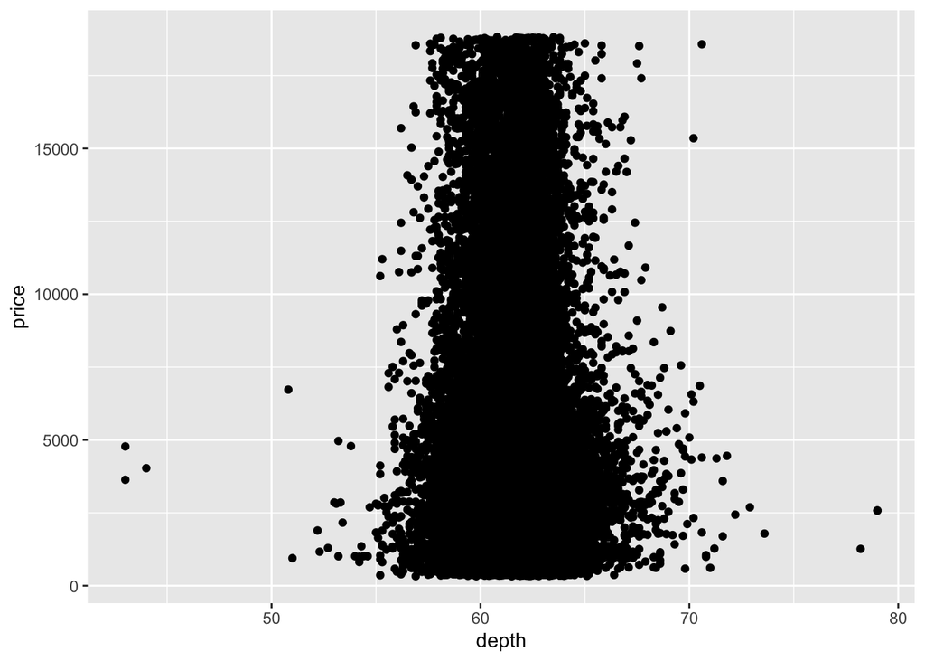

```r
library(ggplot2)
# base ggplot()
# aesthetics / line type
# theme
# geom_line()
# geom_hist()
# geom_bar()
# stat_
data("diamonds")
# aes(x = , y = , color, size, alpha )
# scatterplot = geom_point
ggplot(diamonds) + geom_point( aes(depth, price))
```

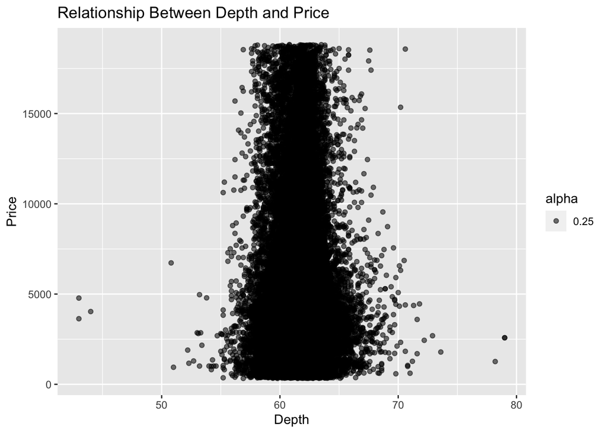

```r
ggplot(diamonds) + geom_point( aes(depth, price, alpha = 0.25))+ggtitle("Relationship Between Depth and Price")+xlab("Depth")+ylab("Price")
```